# Commentary on the different normalization modes

Aaron Lun

2019-12-24

# 1 Cosine normalization

## 1.1 Rationale

If scaling normalization is only performed *within* each batch, there may be a systematic scaling difference in the normalized expression values between batches. This unnecessarily adds an extra dimension to the differences between batches, which complicates later correction steps. Ideally, one would address this problem during normalization (see `multiBatchNorm()` below) but this is not possible for arbitrary log-expression values. Correctly reversing the log-transformation requires knowledge of the base of the log function and the added pseudo-count, which complicates the interface at best and may not be available at worst.

Cosine normalization of the log-expression values represents the next-best solution for removing these differences between batches. Real single-cell data contains many small counts (where the log function is near-linear) or many zeroes (which remain zero when the pseudo-count is 1). In these applications, scaling differences due to separate normalization will not manifest as the expected shift in the log-transformed expression. Rather, they are better represented as scaling differences in the log-expression vectors, which cosine normalization aims to remove.

## 1.2 Preserving orthogonality

If the batch effect was orthogonal to the biological subspace in the un-normalized space, is this still the case after cosine normalization? Not in general - one can imagine a simple 2D scenario where the biological subspace is a horizontal line and the batch effect is a vertial shift. Cosine normalization will map the manifolds onto the unit circle around the origin and break orthogonality.

We can consider the cases where this discrepancy is minimized. If we have the biological subspace $B$ and a batch vector $W$, the cosine-normalized expression without the batch vector is

$$\frac{\mathbf{B}x}{\sqrt{x^T\mathbf{B}^T\mathbf{B}x}} \;,$$

for a cell corresponding to $x$. The cosine-normalized expression after adding the batch vector is

$$\frac{\mathbf{B}x + W}{\sqrt{(\mathbf{B}x + W)^T(\mathbf{B}x + W)}} \;.$$

The difference between the two represents the batch vector in cosine-normalized space. Biological differences in cosine-normalized space can be represented by differences between the cell corresponding to $x$ and another cell corresponding to $y$, i.e.,

$$\frac{\mathbf{B}x}{\sqrt{x^T\mathbf{B}^T\mathbf{B}x}} - \frac{\mathbf{B}y}{\sqrt{y^T\mathbf{B}^T\mathbf{B}y}}$$

for any $y\ne x$. We ask whether the batch vector is orthogonal to an arbitrary biological difference vector, i.e., we look at

$$\begin{align*}
& \left(\frac{\mathbf{B}x}{\sqrt{x^T\mathbf{B}^T\mathbf{B}x}} - \frac{\mathbf{B}y}{\sqrt{y^T\mathbf{B}^T\mathbf{B}y}} \right)^T
\left(\frac{\mathbf{B}x + W}{\sqrt{(\mathbf{B}x + W)^T(\mathbf{B}x + W)}} - \frac{\mathbf{B}x}{\sqrt{x^T\mathbf{B}^T\mathbf{B}x}} \right) \\
& = \left(\frac{x^T\mathbf{B}^T\mathbf{B}x}{\sqrt{x^T\mathbf{B}^T\mathbf{B}x}} - \frac{y^T\mathbf{B}^T\mathbf{B}x}{\sqrt{y^T\mathbf{B}^T\mathbf{B}y}} \right)
\left[ \frac{1}{\sqrt{x^T\mathbf{B}^T\mathbf{B}x + W^TW}} - \frac{1}{\sqrt{x^T\mathbf{B}^T\mathbf{B}x}} \right] \;,
\end{align*}$$

which is only close to zero for arbitrary $y$ when $W^TW$ is small relative to $x^T\mathbf{B}^T\mathbf{B}x$. In other words, the batch effect remains approximately orthogonal if the batches are not too far apart relative to the L2 norm of the expression vector. This is probably reasonable if the batch effect is not as large as the magnitude of expression for each gene.

Of course, this is all rather academic, as one can simply change the orthogonality assumption to refer to the cosine-normalized space in the first place. The cosine-normalized space loses one dimension of variation relative to the un-normalized space, but both are still high-dimensional, so the assumption of orthogonality is still reasonable in the former.

# 2 `multiBatchNorm()` as an alternative

The `multiBatchNorm()` function accepts a number of batches and will downscale the counts in each batch (indirectly via adjustment of size factors) to match the coverage of the lowest-coverage batch. Subsequent normalization and log-transformation will then yield expression values that are more directly comparable between batches.

We deliberately chose to downscale all batches rather than scale all batches to the mean or median coverage. By downscaling, we increase the shrinkage of log-expression values towards zero upon addition of the pseudo-count of 1 in `normalize()`. This suppresses batch-to-batch differences in the technical noise at low counts and improves the quality of the MNN correction. Otherwise, cells in low-coverage batches would be more spread out, making it difficult to identify the correct MNN pairs.

Obviously, biological variation will also experience greater shrinkage towards zero. This is not a major problem as long as this shrinkage is consistent across batches. In fact, the loss of biological variation from increased shrinkage of high-coverage batches is correct if that variation could not have manifested in the low-coverage batches anyway. Low-abundance genes with no expression in low-coverage batches are not informative and should not be used to direct the correction, even if they are expressed and useful in high-coverage batches. (Of course, once the correction is performed based on informative genes, it is entirely possible to obtain corrected values for them.)

These concerns mostly apply to low counts where the variance is highly dependent on the mean. At high counts, the effects of technical noise are less pronounced, mitigating any differences between batches due to coverage. Shrinkage also has less effect, allowing the biological variation to be preserved, e.g., for large counts in upregulated genes.

Rather than downscaling, we could achieve the same effect by downsampling, e.g., with `downsampleCounts()`. This would provide a more accurate match of the mean-variance relationship, but introduces an element of stochasticity (especially at low counts) that may not be desirable. Note that standardization of the per-batch expression matrix is not advisable here as batches with different cell type composition will geniunely exhibit different per-gene variances.

# 3 Practical notes

## 3.1 Setting up the data

To explore the effects of these different modes of normalization, we will use some example datasets. One of these is the classic Zeisel brain dataset:

```r
library(scRNAseq)
library(scater)
library(scran)

X <- ZeiselBrainData()
X <- addPerCellQC(X, subsets=list(Mito=grep("mt-", rownames(X))))
qcX <- quickPerCellQC(colData(X), percent_subsets="subsets_Mito_percent")
X <- X[,!qcX$discard]

X <- logNormCounts(X)
decX <- modelGeneVar(X)
```

The other is the Tasic brain dataset:

```r
Y <- TasicBrainData()
Y <- addPerCellQC(Y, subsets=list(Mito=grep("mt_", rownames(Y))))
qcY <- quickPerCellQC(colData(Y), percent_subsets="subsets_Mito_percent")
Y <- Y[,!qcY$discard]

Y <- logNormCounts(Y)
decY <- modelGeneVar(Y)
```

We combine their variance modelling results in preparation for a combined analysis:

```r
universe <- intersect(rownames(X), rownames(Y))
combined <- combineVar(decX[universe,], decY[universe,])
chosen <- getTopHVGs(combined, n=5000)

X2 <- X[universe,]
Y2 <- Y[universe,]
```

## 3.2 Testing the different normalization strategies

First, we try with both `multiBatchNorm()` and cosine normalization:

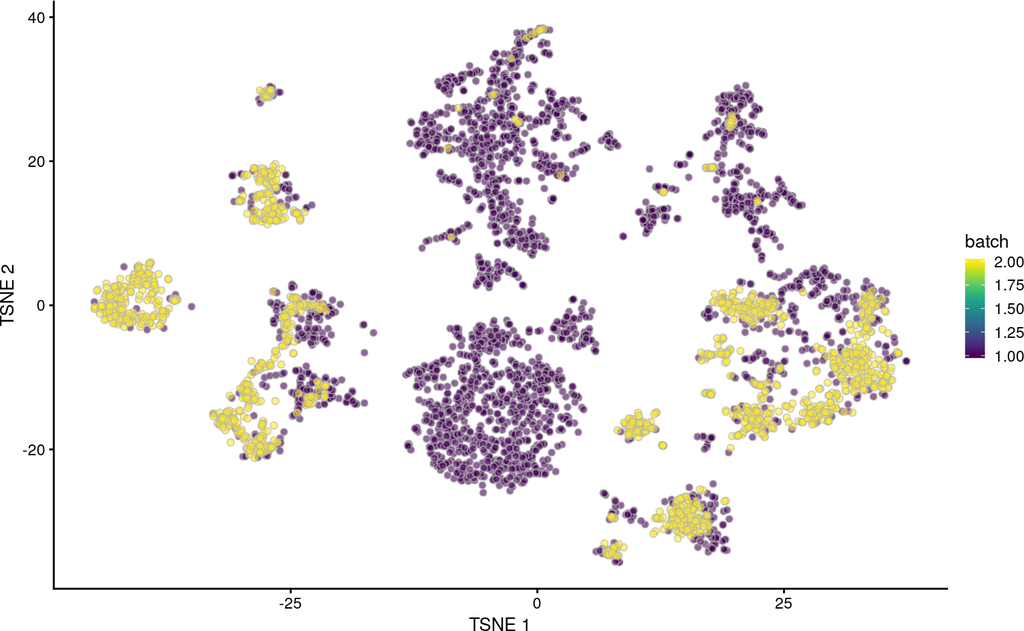

```r
library(batchelor)
stuff <- multiBatchNorm(X2, Y2)

set.seed(10000)
ref1 <- fastMNN(stuff[[1]], stuff[[2]], subset.row=chosen)
ref1 <- runTSNE(ref1, dimred="corrected")
plotTSNE(ref1, colour_by="batch")
```

We repeat with just cosine normalization.

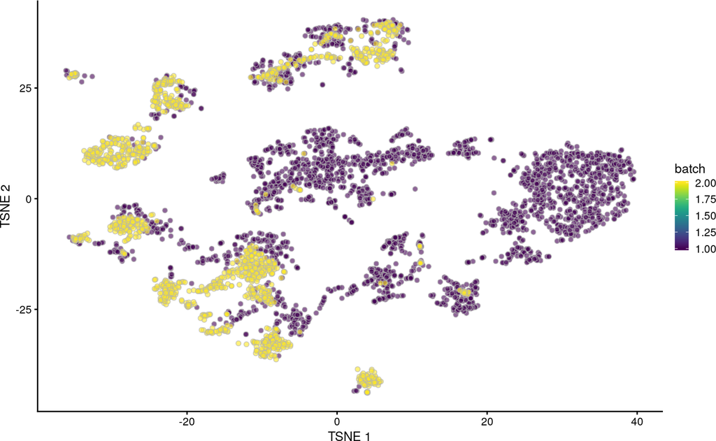

```r
ref2 <- fastMNN(X2, Y2, subset.row=chosen)
ref2 <- runTSNE(ref2, dimred="corrected")
plotTSNE(ref2, colour_by="batch")
```

And finally, without cosine normalization.

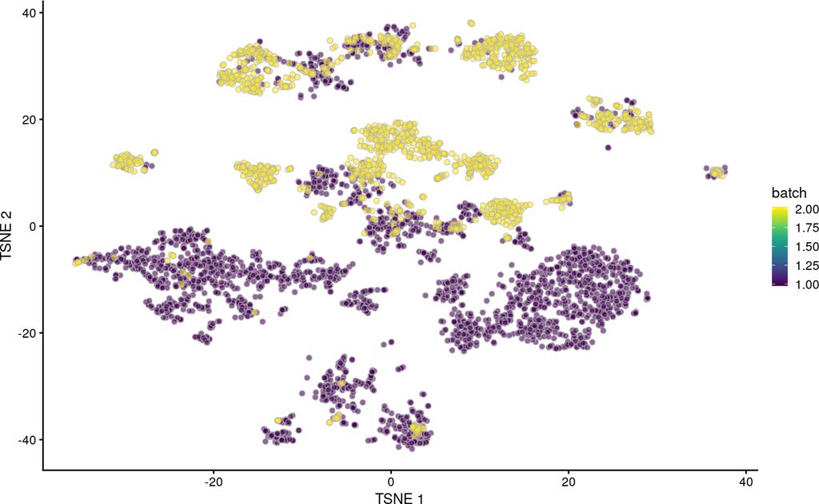

```r
ref3 <- fastMNN(stuff[[1]], stuff[[2]], subset.row=chosen, cos.norm=FALSE)
ref3 <- runTSNE(ref3, dimred="corrected")
plotTSNE(ref3, colour_by="batch")
```

Cosine normalization provides the most benefit in the case study above, probably because it is applied after subsetting to HVGs. Tis removes variation due to systematic differences in HVG expression within each batch, reducing the risk of incomplete mixing - indeed, we see from below that the high-L2 cells form their own cluster if cosine normalization is not performed. `multiBatchNorm()` also improves mixing to limited extent, most likely due to a similar effect of removing variation in the higher-coverage batch by squeezing all expression values towards zero.

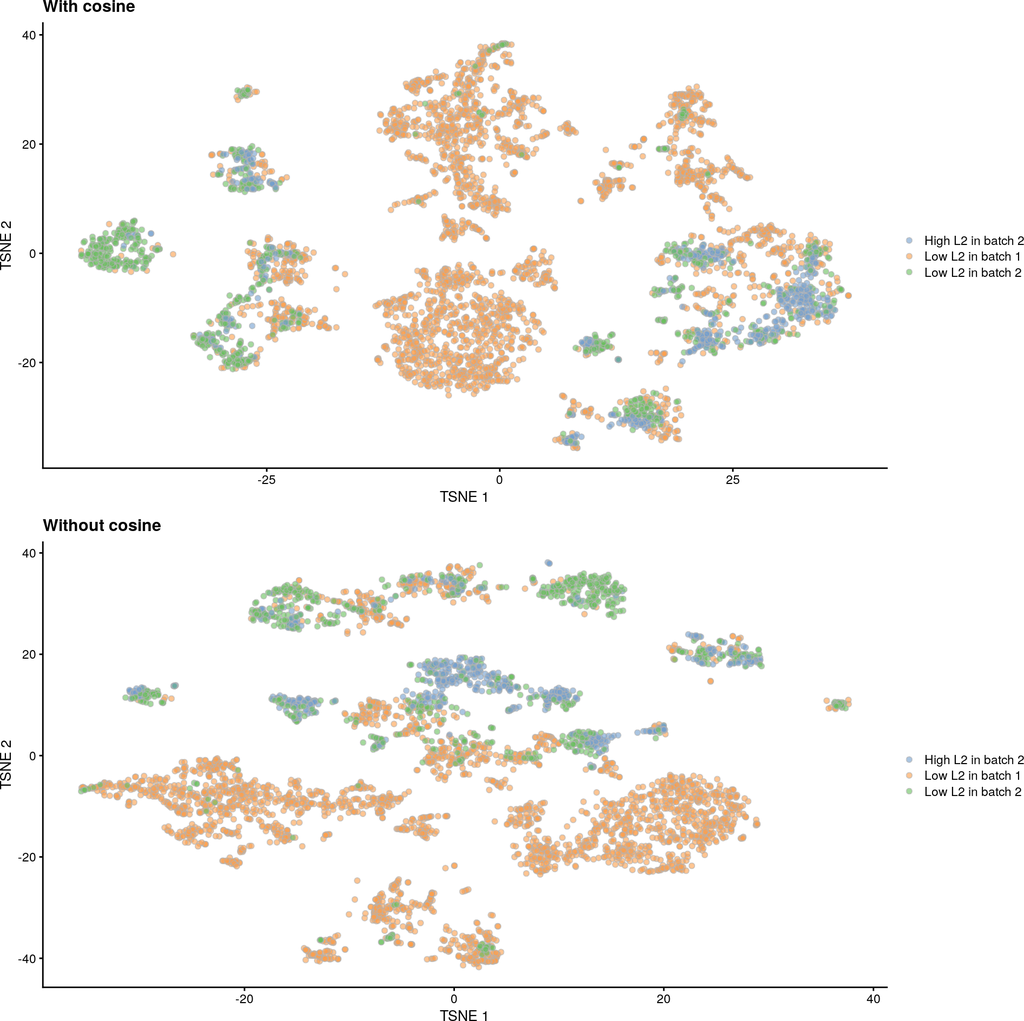

[output not shown]

[output cut: 61 more lines]

```r
l2 <- c(cosineNorm(logcounts(stuff[[1]])[chosen,], mode="l2"),
    cosineNorm(logcounts(stuff[[2]])[chosen,], mode="l2"))

batch.l2 <- paste(ifelse(l2 < 100, "Low L2", "High L2"),
    "in batch", ref3$batch)

gridExtra::grid.arrange(
    plotTSNE(ref1, colour_by=I(batch.l2)) + ggtitle("With cosine"),
    plotTSNE(ref3, colour_by=I(batch.l2)) + ggtitle("Without cosine")
)
```